# La Política de la Corrupción

Sesión 7: Repaso para el examen parcial

Bogdan G. Popescu

bgpopescu@tec.mx

Tecnológico de Monterrey

## Hoy

La clase de hoy tiene cuatro partes.

- **Dónde estamos** — la forma del curso y cómo se arma la calificación.
- **El examen** — cuándo, dónde, cuánto dura y cómo se ve.
- **Las herramientas** — los ocho actos y, después, las ideas de las Sesiones 2 a 6 que vienen en el examen.
- **Práctica** — seis ejercicios, con las respuestas resueltas.

# Parte I — Dónde estamos

## El curso en tres partes

|  | Sesiones | De qué trata |
| --- | --- | --- |
| **I. Conceptos y medición** | 1–5 | qué *es* la corrupción y cómo leer la evidencia sobre ella |
| **II. Historia y comparación** | 6–10 | cómo creció y cómo algunos países salieron de ella |
| **III. Un mundo globalizado** | 11–14 | ayuda, recursos, crimen organizado, tecnología |

**El examen del jueves cubre solo las Sesiones 1–6.**

## Cómo se arma la calificación

- **Participación en clase — un tercio**
  - tu presentación de 10 minutos
  - asistencia
  - participación en clase
  - las preguntas semanales
  - la *calidad* de esas preguntas
- **Examen parcial — un tercio**
- **Examen final — un tercio**

# Parte II — El examen

## Cuándo, dónde, cuánto dura

| **Cuándo** | jueves 24 de septiembre, en clase |
| --- | --- |
| **Dónde** | en Canvas, en tu propia pantalla |
| **Cuánto dura** | **30 minutos** |
| **Qué cubre** | Sesiones 1–6 |
| **Cuánto vale** | 33% de tu calificación |

**A libro cerrado.** Sin notas, sin libros, sin más pestañas que Canvas.

## El examen

Seis partes cortas, veintisiete reactivos. Diecisiete de ellos solo piden una etiqueta o una letra.

| Parte | Qué pide | Cómo se ve la respuesta |
| --- | --- | --- |
| **A** | Nombra el acto | un nombre de una lista impresa |
| **B** | Nombra el concepto | una frase de una lista impresa |
| **C** | ¿Qué cambiarías primero? | una etiqueta **+ una oración** |
| **D** | Explica el patrón | una frase **+ unas pocas palabras** |
| **E** | Lee el estudio | dos respuestas, de 2 a 3 oraciones cada una |
| **F** | Relaciona la lectura | una letra |

**El jueves, cada lista trae una opción por pregunta: usas cada opción una sola vez.** La excepción es la Parte F, que trae una opción de más.

Hoy, en cambio, cada ejercicio trae una opción de más. Así la última respuesta no sale sola por descarte: tienes que saberla.

# Parte III — Las herramientas, sesión por sesión

## Sesión 1 — Qué cuenta como corrupción

Estas ocho palabras nombran ocho cosas distintas que puede hacer un funcionario. No son ocho tamaños de lo mismo. Un solo caso puede involucrar varias, pero en el examen cada nombre se usa una vez.

| **Soborno** | pago para sortear un obstáculo real, o para cambiar una decisión real |
| --- | --- |
| **Extorsión** | el funcionario inventa el obstáculo y luego vende la salida |
| **Peculado** | dinero que ya estaba a tu cargo, tomado |
| **Fraude** | engaño — facturas falsas, trabajadores que no existen |
| **Tráfico de influencias** | vender acceso **indebido** a quien decide |
| **Clientelismo** | beneficios repetidos a cambio de apoyo político |
| **Patronazgo** | empleos públicos a cambio de lealtad política |
| **Captura del Estado** | las empresas reguladas escriben ellas mismas las reglas |

El soborno y la extorsión pueden verse idénticos: el mismo dinero, la misma oficina, y en ambos el funcionario puede hablar primero. Lo que los distingue es si el problema ya estaba ahí. **La fila de Sofía era real. La norma del inspector sanitario no.**

## Soborno

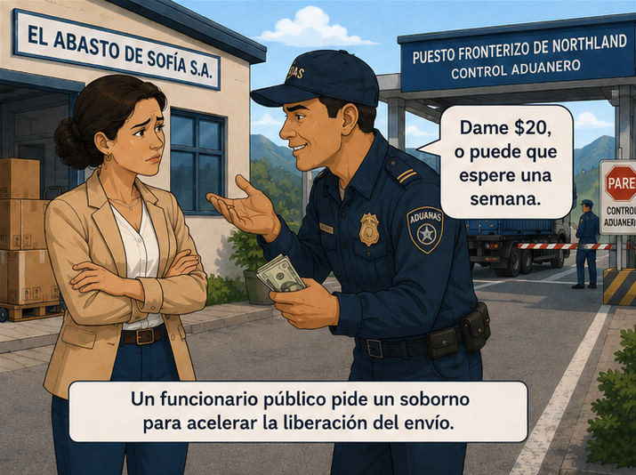

La demora en la frontera es real, y el funcionario sí la controla. Sofía paga para avanzar en una fila que ya existía.

## Extorsión

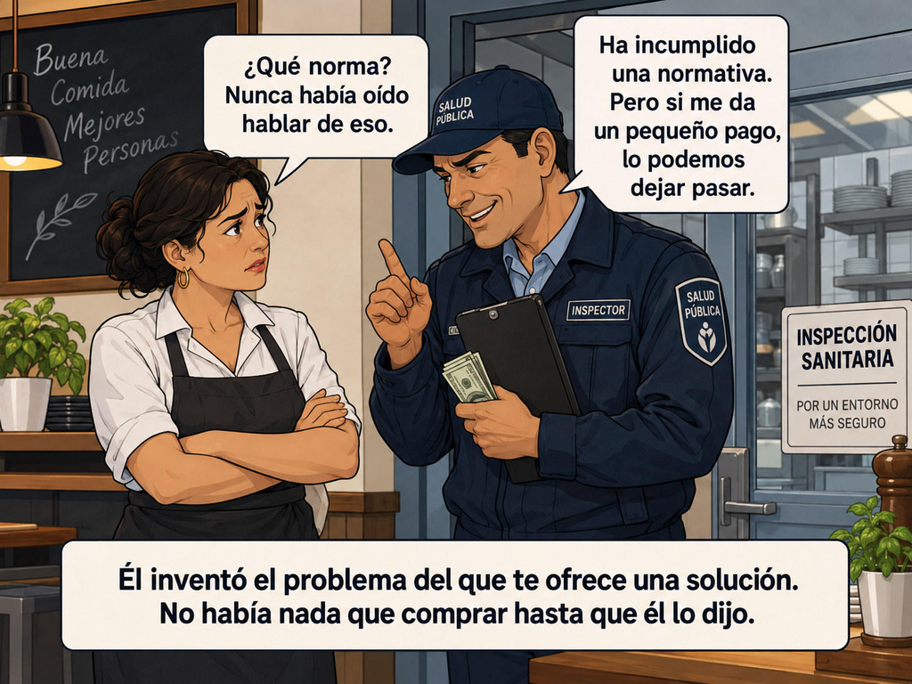

Compáralo con Sofía. La demora de ella era real. Esta norma no.

## Peculado

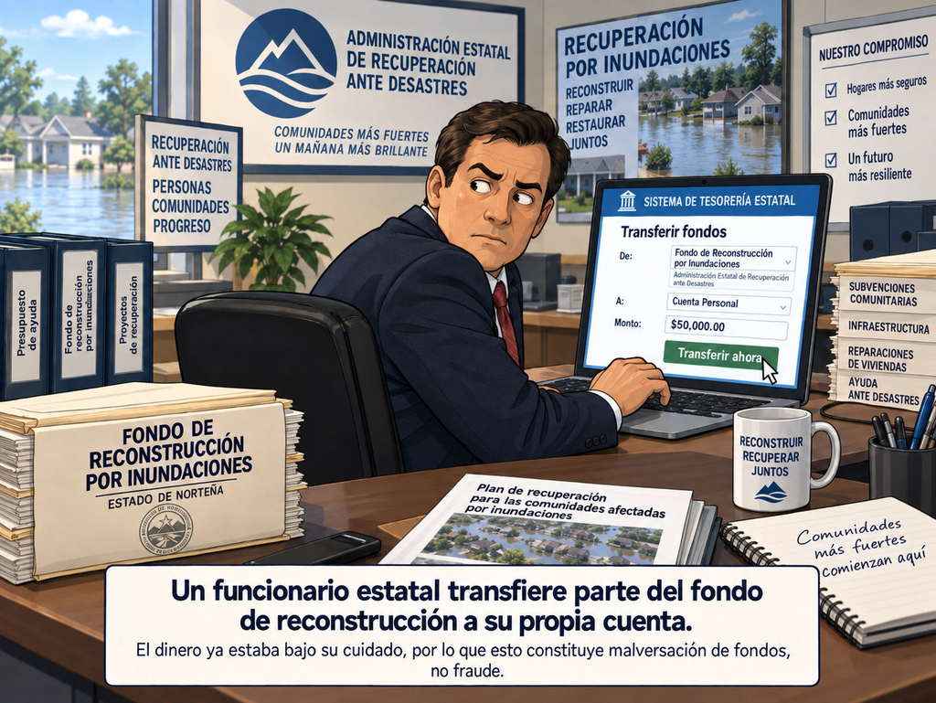

## Fraude

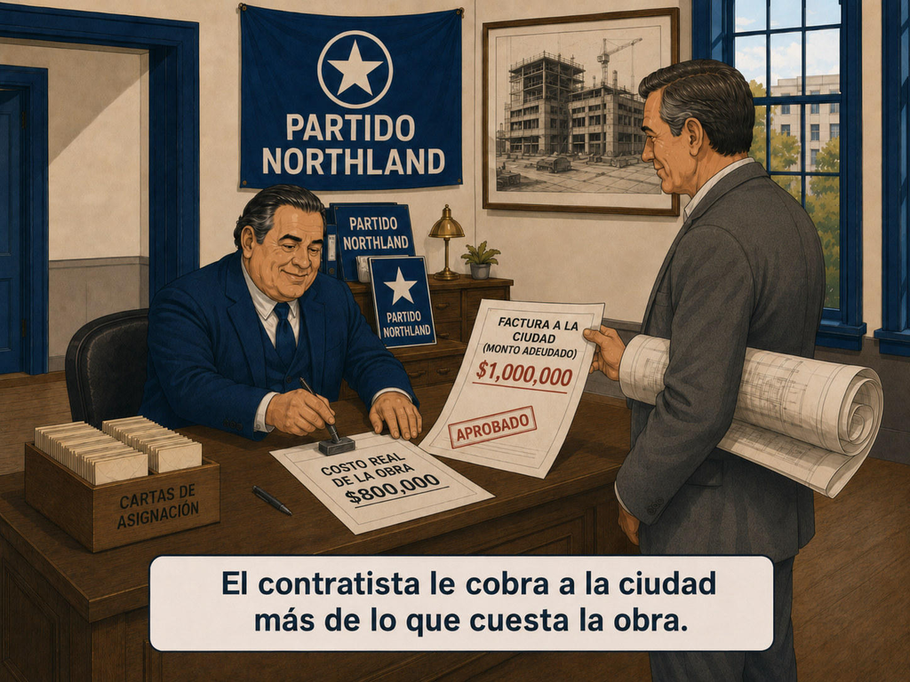

El contratista nunca tuvo el dinero de la ciudad. Lo obtuvo haciendo que la factura dijera algo falso.

## Tráfico de influencias

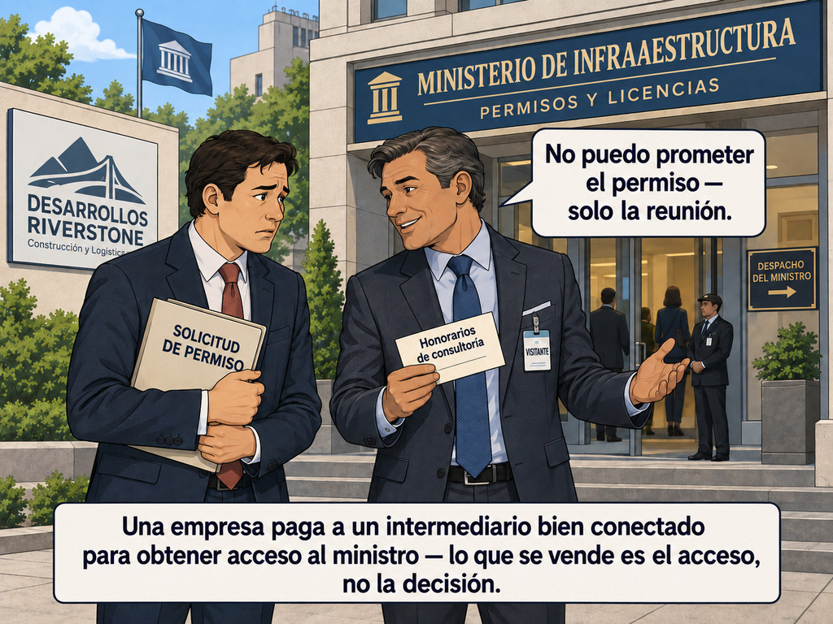

Dónde deja esto de ser cabildeo ordinario es discutido, y cada país traza la línea en un lugar distinto.

## Clientelismo

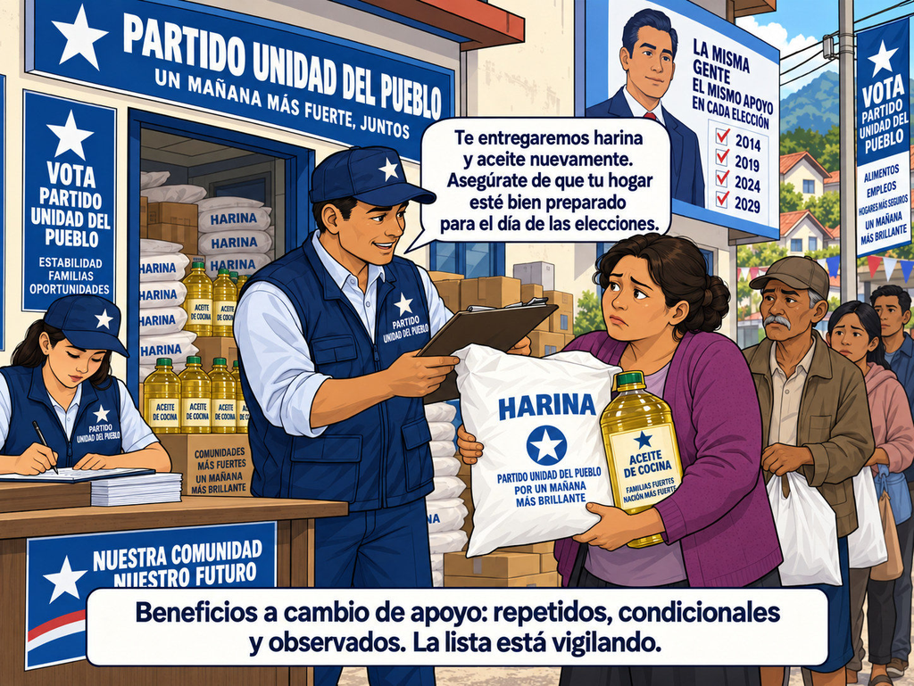

## Clientelismo o compra de votos

En los dos, un político da algo a cambio de apoyo. **Lo que se entrega no los distingue**: la misma bolsa de harina puede ser cualquiera de los dos. Lo que los separa es **cuánto dura el trato**.

|  | Compra de votos | Clientelismo |
| --- | --- | --- |
| **Cuántas veces** | una sola, en tiempos electorales | una y otra vez, elección tras elección |
| **Qué queda después** | nada: se pagó y se acabó | una relación: el beneficio sigue mientras siga el apoyo, y alguien lo vigila |
| **Con la harina** | una bolsa, una vez, la semana de la elección | “te entregaremos harina *nuevamente*”, 2014, 2019, 2024, 2029, y una lista con nombres |

Por eso la imagen anterior es clientelismo, y no por la harina. Las pistas son la palabra *nuevamente*, los años en la manta y la lista. Pregúntate qué pasa después de la elección: si el trato se acaba ahí, es compra de votos; si vuelve en la siguiente, es clientelismo.

## Patronazgo

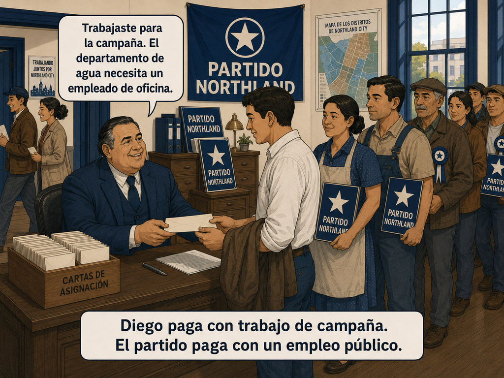

A Diego le pagan con un empleo, y se lo pagan por el trabajo de campaña que hizo, no por su voto.

## Captura del Estado

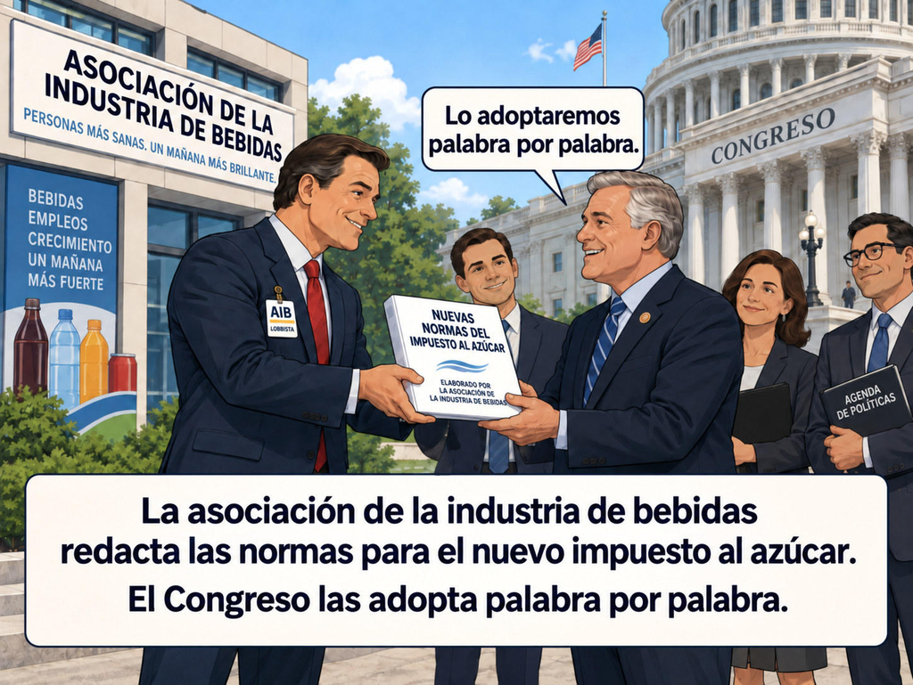

Aquí nadie entrega dinero. La industria consigue lo que quiere en el momento en que se escribe la regla, y una vez aprobada, lo que esa regla protege queda dentro de la ley.

## Sesión 2 — Cómo leer un estudio

La Sesión 2 te dio seis movimientos. Tres son los que pide el jueves.

- **Medición** — qué se contó en realidad, **y en qué nivel**. Aquello que un estudio dice estudiar rara vez es lo que de verdad contó.
- **Comparación** — ¿comparado con *qué*?
- **Rivales** — ¿qué más produciría este mismo patrón? ¿Esta evidencia permite distinguirlos?

**¿Comparado con qué?** Casi siempre con una de dos cosas: con otros países en el mismo momento, o con el mismo país antes y después de un cambio.

Comparar países deja adentro todo lo demás que los hace distintos. Comparar antes y después mantiene fijo al país mismo.

Y cuando un autor dice que **tomó en cuenta el ingreso**, lo que hizo fue quitar lo que ese único número explica, y nada más. Todo lo que nunca midió sigue ahí adentro.

## Sesión 3 — Las tres preguntas de Klitgaard

$$\text{Corrupción} = \text{Monopolio} + \text{Discrecionalidad} - \text{Rendición de cuentas}$$

*Es una regla para recordar, no un cálculo. Te dice dónde buscar.*

- **Monopolio** — ¿el ciudadano puede ir a otra parte?
- **Discrecionalidad** — ¿quién decide, y contra qué regla escrita?
- **Rendición de cuentas** — ¿quién puede enterarse **y quién puede sancionar?**

Las dos mitades importan. Publicar una decisión permite que la gente se entere, pero si nadie puede actuar con lo que encuentra, publicar no basta.

## Sesión 3 — Shleifer y Vishny: ¿robo a quién?

Los dos nombres confunden. El robo es **al Estado**, no a Sofía.

- **Sin robo** — el fisco sí recibe su tarifa.
- **Con robo** — el fisco no recibe nada.

Esa es toda la diferencia entre los dos nombres.

[figure not shown]

## Sin robo

La tarifa aduanal legal es de $100.

Sofía paga **$120**. El funcionario entrega $100 al Estado y se queda con $20.

Pagó $20 más de lo que pide la ley. Está peor que si todos hubieran seguido las reglas, así que tiene motivos para quejarse.

## Con robo

La tarifa aduanal legal es de $100.

Sofía paga **$60**. El funcionario no registra nada y se queda con todo. El Estado no recibe **nada**.

Pagó $40 menos de lo que pide la ley. Está mejor que si todos hubieran seguido las reglas.

Por eso nunca lo va a denunciar. Y por eso este es el más difícil de detener.

## Los dos, lado a lado

|  | Sofía paga | El Estado recibe | El funcionario se queda | ¿Se quejaría? |
| --- | --- | --- | --- | --- |
| Siguiendo las reglas | 100 | 100 | 0 |  |
| **Sin robo** | 120 | 100 | 20 | sí, pagó más de lo que pide la ley |
| **Con robo** | 60 | 0 | 60 | no, sale ganando |

Pregúntate quién pierde. Sin robo pierde Sofía, y ella puede ser testigo. Con robo pierde el Estado, y las dos únicas personas en la sala salen ganando.

## Sesiones 3–4 — Principal–agente

Alguien le encarga un trabajo a otra persona y no puede vigilar cómo lo hace.

- **El principal** — el supervisor. Quiere que los permisos se expidan bien.
- **El agente** — el empleado de ventanilla. Quiere los veinte dólares.
- Quieren cosas distintas, y solo uno de los dos está en la ventanilla.
- El empleado sabe qué pasó ahí. El supervisor no.

Ese hueco tiene nombre: **asimetría de información**. Es lo que hace posible la traición.

La solución parece obvia: vigilar más de cerca, auditar, subir la sanción. Funciona porque **alguien arriba quiere que se arregle**.

## Sesión 4 — Acción colectiva

Imagina que eres el único empleado honesto de la oficina.

- Rechazas los veinte dólares. El solicitante se pasa a la siguiente ventanilla.
- Tus compañeros los siguen aceptando, así que ganas menos que todos ellos.
- Nada cambia en la oficina.

Negarte te cuesta algo y no cambia nada, así que dejas de negarte. Lo que te conviene depende de lo que esperas que hagan todos los demás.

Todos estarían mejor si nadie pagara. Cada persona por separado sigue estando mejor si paga.

**Y no hay nadie arriba que lo arregle.** El supervisor también recibe su parte.

## Sesión 4 — Dos maneras de leer la misma oficina

|  | ¿Hay alguien arriba dispuesto a actuar? | Qué lo arreglaría |
| --- | --- | --- |
| **Principal–agente** | sí | mejor vigilancia, sanciones más altas |
| **Acción colectiva** | no | nada que una sola persona pueda cambiar |

Casi toda reforma anticorrupción está hecha para el renglón de arriba. Da por sentado que alguien con mando quiere frenar esto y que solo le faltan mejores herramientas para atrapar a los de abajo.

Lo que señalan Persson, Rothstein y Teorell es que en el renglón de abajo esa persona no existe.

## Sesión 4 — Por qué una sanción más alta no ayuda

Todos los empleados reciben pagos. Todos los solicitantes pagan. La secretaría **duplica la multa**.

Lo que de verdad arriesga un empleado no es la multa en el papel:

$$\text{lo que me cuesta} = \text{la multa} \times \text{la probabilidad de que alguien la aplique}$$

- Duplicar la multa duplica el **primer** número.
- El **segundo** número es casi cero. Quienes tendrían que aplicarla están recibiendo su parte.
- El doble de casi nada sigue siendo casi nada.

## Sesión 4 — El experimento de Corbacho

Costa Rica. A cada quien se le asignó **al azar** a uno de tres grupos.

| Grupo | Qué se le mostró |
| --- | --- |
| Un tercio | cifras reales de encuesta: quienes dijeron haber presenciado corrupción pasaron de 16% a 24% |
| Un tercio | un volante con malas noticias igual de graves, sobre la lentitud de los tribunales |
| Un tercio | nada |

El segundo grupo es el placebo. Muestra que no fueron las malas noticias en general las que movieron a la gente.

## Sesión 4 — Qué encontró el experimento

**35% contra 27%.** El grupo que vio las cifras de corrupción estuvo más dispuesto a sobornar a un agente de tránsito. El grupo placebo no se movió.

Los grupos se formaron al azar, así que nada de lo que son esas personas explica la diferencia. Solo la explican las cifras de corrupción.

Una advertencia. Esto es lo que la gente dijo que haría. Nadie vio a nadie pagar un soborno.

## Sesión 5 — Cuánto cuesta la corrupción

Mauro comparó **67 países**. Donde la burocracia es peor, hay **menos inversión**.

Pero los países difieren en muchas cosas a la vez, así que no puedes saber cuál de esas diferencias está haciendo el trabajo.

Comparar países no te dice cuánto cuesta la corrupción. Hace falta algo que separe la causa de todo lo demás que viaja con ella.

## Sesión 5 — Lo que te da un sorteo

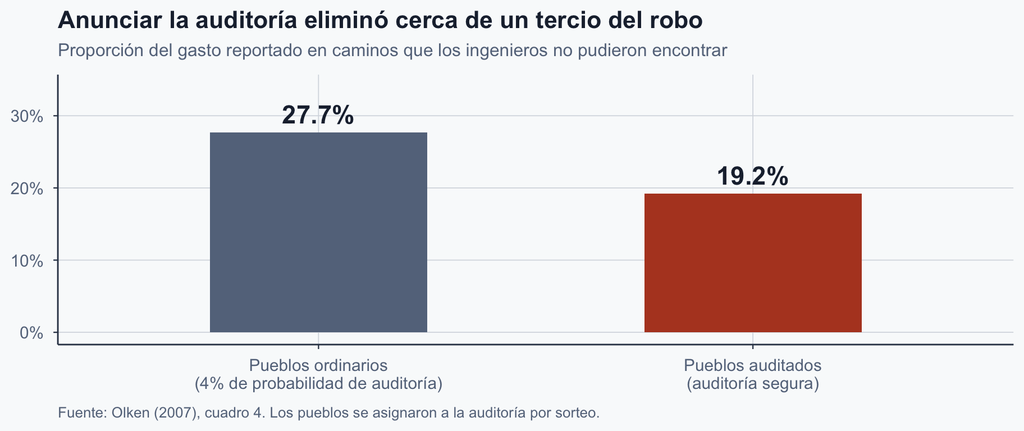

El sorteo decidió qué pueblos se auditaban, así que nada de lo que es un pueblo explica la diferencia. Solo la explica la auditoría.

## Sesión 5 — Cuatro maneras en que surge un patrón

- **Lo primero causa lo segundo.** La conclusión que uno normalmente quiere.
- **Lo segundo causa lo primero.** La causa y el efecto van al revés.
- **Otra cosa causa las dos.** *Tienes que decir cuál es.*
- **No hay conexión real.** Se compararon tantas cosas que alguna iba a coincidir por casualidad.

Compara los resultados de un examen contra sesenta cosas de los estudiantes y algo va a coincidir: el número de zapato, el mes de nacimiento, el color de la mochila. La pista es cuántas comparaciones se hicieron.

## Sesión 6 — Wallis: ¿hacia dónde apunta la flecha?

```
%%{init: {"theme": "base", "width": 1200, "height": 400, "fontSize": 16, "themeVariables": {"fontSize": "16px", "fontFamily": "Helvetica, Arial, sans-serif", "primaryColor": "#eef2f6", "primaryTextColor": "#1e293b", "primaryBorderColor": "#334155", "lineColor": "#b44527", "edgeLabelBackground": "#f9…
flowchart LR
  A["CARGO PÚBLICO<br/>el poder de decidir"]
  B["BENEFICIOS ECONÓMICOS<br/>dinero, empleos, contratos"]
  A -- "VENAL<br/>usar el cargo para lucro económico privado" --> B
  B -- "SISTEMÁTICA<br/>usar privilegios económicos para sostener el poder político" --> A
  classDef box fill:#eef2f6,stroke:#334155,stroke-width:2px,color:#1e293b;
  class A,B box;
```

“Sistemática” **no** quiere decir “generalizada”. Describe cómo la corrupción mantiene a un partido en el poder.

Esta es una **pregunta distinta** de la de la Sesión 3. *Con robo o sin robo* pregunta con qué se queda el fisco. *Venal o sistemática* pregunta qué compra el intercambio. Un mismo caso puede ser las dos cosas.

## Sesión 6 — ¿De qué tipo?

1. Un inspector de aduanas cancela un impuesto de importación a cambio de un pago en efectivo. — **venal**
2. Un alcalde compra terrenos sobre el trazo de una línea de metro antes de que se anuncie. — **venal**
3. Todas las empresas que ganan obra pública municipal donan también al partido gobernante. — **sistemática**
4. Solo los bancos cuyos directivos apoyan a la facción gobernante reciben concesiones. — **sistemática**

**Pregúntate qué compra el intercambio.**

|  | Qué compra | Tipo |
| --- | --- | --- |
| 1 y 2 | una ganancia privada | **venal** |
| 3 y 4 | una coalición que mantiene a la facción en el poder | **sistemática** |

## Sesión 6 — Una prueba que puedes aplicar

Mete a la cárcel a todos los involucrados. Pon gente honesta en cada silla. ¿Ahora qué?

|  | Qué pasa | Por qué |
| --- | --- | --- |
| **Venal** | se detiene | necesitaba a alguien deshonesto |
| **Sistemática** | sigue igual | los privilegios siguen ahí, y quien ocupe el cargo sigue necesitando una mayoría |

La corrupción venal necesita gente mala. La corrupción sistemática solo necesita el arreglo.

Por eso la reforma funcionó quitando lo que había que vender, y no reemplazando a las personas.

# Parte IV — Práctica

## Ejercicio 1 — Nombra el acto

**Un nombre para cada uno. Sobra un nombre.** Elige entre: soborno, extorsión, peculado, fraude, tráfico de influencias, clientelismo, patronazgo, captura del Estado, compra de votos.

1. Una directora de escuela gasta el presupuesto de mantenimiento en un coche para ella.
2. Un policía detiene a un conductor que no hizo nada y le dice que puede pagar ahora o pasar la noche en la comandancia.
3. Un padre de familia le paga a un empleado de la universidad para que mueva un expediente de inscripción al frente de la fila.
4. Un proveedor factura a la ciudad quinientas comidas escolares al día y entrega doscientas.
5. El único personal técnico que tiene el regulador de telecomunicaciones está prestado por la industria que regula, y todos los borradores de reglas salen de ahí.
6. Un exgobernador cobra por conseguirle a un contratista una reunión privada con el funcionario que decide sobre su licitación.
7. Un regidor rehabilita el drenaje de las calles que votaron por él después de cada elección, y el comité vecinal le entrega la lista de quién votó, calle por calle.
8. Un nuevo director de museo sustituye a todo el personal de taquilla por gente de la organización juvenil de su partido.

## Ejercicio 1 — resuelto

|  | El caso | Respuesta | Por qué |
| --- | --- | --- | --- |
| 1 | el presupuesto de mantenimiento en su propio coche | **peculado** | el dinero ya estaba a su cargo |
| 2 | pagar ahora o pasar la noche en la comandancia | **extorsión** | él inventó el problema del que vende la salida |
| 3 | pagar por adelantarse en la fila de inscripción | **soborno** | la fila es real; paga por adelantarse en ella |
| 4 | cobra 500 comidas, entrega 200 | **fraude** | la factura dice algo falso |
| 5 | la industria pone el personal del regulador y escribe sus borradores | **captura del Estado** | las reglas mismas las escribe la industria |
| 6 | un cobro para llegar al funcionario que decide | **tráfico de influencias** | lo que se vende es el acceso, no la decisión |
| 7 | drenaje para las calles que votaron, después de cada elección | **clientelismo** | beneficios a cambio de apoyo, una y otra vez |
| 8 | taquilla sustituida por la organización juvenil del partido | **patronazgo** | empleos públicos repartidos por lealtad política |

Los reactivos 2 y 3 son los que hay que acertar. Pregúntate quién hizo el problema. La fila del 3 ya estaba ahí antes de que nadie hablara; la falta del 2 nunca existió.

**Sobra: compra de votos** — una compra única en tiempos electorales. El 7 pasa después de cada elección, y es esa repetición la que lo hace clientelismo.

## Ejercicio 2 — Nombra el concepto

**Una frase para cada uno. Sobra una etiqueta.** Elige entre: corrupción con robo, corrupción sin robo, corrupción sistemática, corrupción venal, captura del Estado. Los reactivos 1 y 2 son sobre con qué se queda el fisco. Los reactivos 3 y 4 son sobre en qué dirección corre la influencia.

1. Un inspector de mercados le dice a una comerciante que la cuota de su puesto es de 250 pesos y no los 500 de ley, no extiende recibo y se queda con todo.
2. Un hospital registra la cuota oficial de consulta y la deposita en la cuenta del Estado, y el médico le pide a esa misma paciente un pago adicional para atenderla esta semana.
3. Un ingeniero municipal aprueba los planos de construcción de su primo a cambio de uno de los departamentos.
4. Un gobernador entrega las únicas licencias de distribución de alcohol a las familias que financian su campaña, y ese financiamiento es lo que lo mantiene en el cargo.

## Ejercicio 2 — resuelto

|  | El caso | Respuesta | Por qué |
| --- | --- | --- | --- |
| 1 | 250 pesos en vez de los 500 de ley, sin recibo, se queda con todo | **con robo** | el fisco no recibe nada, y la comerciante paga menos de lo que debe |
| 2 | cuota oficial depositada, pago extra para adelantar la consulta | **sin robo** | el fisco sí recibe su cuota; el pago va por encima |
| 3 | planos aprobados a cambio de un departamento | **venal** | usa el cargo para obtener algo para sí mismo: cargo → dinero |
| 4 | licencias solo para quienes financian la campaña | **sistemática** | las licencias son lo que lo mantiene en el cargo |

Mete a todos a la cárcel en el caso 4 y el arreglo sigue funcionando. Haz lo mismo en el caso 3 y se detiene.

**Sobra: captura del Estado** — eso es sobre quién escribe las reglas, no sobre en qué dirección corre un intercambio.

## Ejercicio 3 — ¿Qué cambiarías primero?

**Una etiqueta y una oración. Sobra una etiqueta.** 1 punto por la etiqueta, 2 por la oración, que debe decir quién no puede hacer qué. Elige entre: reducir el monopolio, reducir la discrecionalidad, aumentar la rendición de cuentas, sustituir al funcionario, o ninguna de las anteriores: es un problema de acción colectiva.

1. Solo un laboratorio en el país puede certificar que un producto alimenticio es seguro para exportarse.
2. Un funcionario de vivienda decide quién recibe un departamento subsidiado. No hay una lista escrita de criterios, y la espera va de dos meses a seis años.
3. Las decisiones del registro público se asientan en papel en la misma oficina que las tomó, y ningún otro órgano puede revisarlas.
4. Todos los examinadores de manejo reciben un pago, todos los aspirantes pagan y ambas partes lo dicen abiertamente — y los supervisores de los examinadores reciben parte de cada pago. La secretaría anuncia una línea de denuncia, atendida por esos supervisores.

## Ejercicio 3 — resuelto

|  | El caso | Respuesta | La oración que gana los dos puntos |
| --- | --- | --- | --- |
| 1 | un solo laboratorio, sin alternativa | **reducir el monopolio** | la exportadora no puede ir a ninguna otra parte, así que no puede negarse |
| 2 | sin criterios escritos, dos meses o seis años | **reducir la discrecionalidad** | nada dice cómo debe decidir, así que la diferencia entre dos meses y seis años es suya para venderla |
| 3 | registros en papel, sin revisión externa | **aumentar la rendición de cuentas** | nadie de fuera puede enterarse, y nadie de fuera puede actuar |
| 4 | todos pagan, todos reciben, una línea atendida por los supervisores | **ninguna de las anteriores: acción colectiva** | la línea reporta a los supervisores, que también reciben su parte, así que no hay nadie arriba dispuesto a actuar |

La etiqueta vale un punto. La oración de la columna derecha vale los otros dos.

**Sobra: sustituir al funcionario** — la Sesión 4 mostró por qué. Corre a los dos peores y los reemplazos aprenden la tarifa en una semana.

## Ejercicio 4 — Explica el patrón

**Una frase y unas pocas palabras.** Elige entre: lo primero causa lo segundo; lo segundo causa lo primero; otra cosa causa las dos; no hay conexión real; hay muy pocos casos para saberlo. Sobra una. Cuando un reactivo compara dos cosas, “lo primero” es lo que se nombra primero.

1. “Se pusieron inspectores de boletos en la mitad de las rutas de autobús de una ciudad, elegidas por sorteo. La evasión bajó en las rutas elegidas.”
2. “Un periódico probó sesenta posibles explicaciones de qué escuelas obtienen mejores resultados. La que más coincidió fue qué tan lejos está la escuela del mar.”
3. “Los hospitales con más inspectores de seguridad son los que tienen más accidentes. A esos hospitales se les mandaron inspectores después de una serie de accidentes.”
4. “Los niños que toman clases particulares también comen mejor en casa. Entonces las clases particulares mejoran la alimentación de un niño.”

## Ejercicio 4 — resuelto

|  | El caso | Respuesta | Por qué |
| --- | --- | --- | --- |
| 1 | rutas elegidas por sorteo, la evasión bajó | **lo primero causa lo segundo** | el sorteo deja las rutas parejas de antemano, y solo se hizo una comparación |
| 2 | sesenta explicaciones probadas, la distancia al mar coincidió | **no hay conexión real** | sesenta intentos, así que alguno iba a coincidir |
| 3 | inspectores enviados tras una serie de accidentes | **lo segundo causa lo primero** | los accidentes fueron primero, y son la razón de que haya inspectores |
| 4 | clases particulares y comer mejor en casa | **otra cosa causa las dos** | el ingreso familiar compra las dos cosas |

En el reactivo 4 tienes que decir cuál es esa otra cosa. Responder “otra cosa causa las dos” y detenerte ahí gana 1 punto de los 3. Nombrar “el ingreso familiar” gana los otros dos.

**Sobra: hay muy pocos casos para saberlo** — la mitad de las rutas de una ciudad, sesenta explicaciones, todo un sistema hospitalario, toda una generación de niños. A ninguno le faltan casos.

## Ejercicio 5 — Lee el estudio

Un estudio reporta que, en 90 países, aquellos con más periódicos por habitante obtienen mejor puntaje en un índice de corrupción. La cifra de corrupción es un índice construido a partir de encuestas a ejecutivos de negocios internacionales, con una sola calificación por país, todas levantadas en el mismo año. El autor ya tomó en cuenta el ingreso de cada país. Concluye que una prensa libre reduce la corrupción.

**De dos a tres oraciones por respuesta.**

**(a)** ¿Qué se midió en realidad, y quién lo midió? Nombra un problema y di por qué importa.

**(b)** ¿Comparado con qué? Di contra qué se compara cada país, y nombra una explicación rival que esa comparación no puede descartar.

## Ejercicio 5 — qué hace una respuesta de puntaje completo

**(a)** Mide corrupción **percibida**. Lo que se recogió son las opiniones de ejecutivos internacionales, con una calificación por país.

*El problema:* esos ejecutivos pueden estar calificando la riqueza de un país, su libertad de prensa o su reputación, y no su conducta. Si en parte leen “prensa libre” como “limpio”, el hallazgo viene incorporado en la forma en que se construyó la calificación.

**(b)** Cada país se compara con **otros países**, nunca con su propio pasado. No hay un antes y un después dentro de ningún país.

*La rival:* **qué tan fuerte es el Estado** — qué tan antigua es la administración, qué tan bien dotada de personal, qué tanto sigue sus propias reglas. Los Estados fuertes imprimen más periódicos *y* tienen oficinas más limpias. Decir “son más ricos” por sí solo no gana nada: tomar en cuenta el ingreso solo quita la parte de esa historia que ese único número capta.

## Ejercicio 6 — Relaciona la lectura

Una letra para cada una. Sobra una opción.

1. Klitgaard, *Controlling Corruption*
2. Shleifer y Vishny, “Corruption”
3. Persson, Rothstein y Teorell, “Why Anticorruption Reforms Fail”
4. Wallis, “The Concept of Systematic Corruption in American History”
5. Mauro, “Corruption and Growth”
1. por qué quien pagó puede querer que no se sepa
2. cómo los favores económicos mantuvieron en el poder a un grupo gobernante
3. por qué una ley más dura no cambia nada cuando nadie la va a aplicar
4. una guía para decidir qué oficinas están en mayor riesgo
5. si los países con peor burocracia también reciben menos inversión
6. por qué pagarles mejor a los funcionarios no basta para detenerlos

**1** una guía de oficinas en riesgo · **2** por qué quien paga se queda callado · **3** por qué una ley más dura no cambia nada · **4** cómo los favores económicos mantuvieron a un grupo en el poder · **5** burocracia e inversión.

En el examen las opciones están redactadas de otra forma y llevan otras letras. Relaciona la **idea**, no la letra.